#Master in Computer Vision and Intelligente Machines #Final presentation for 1st semester project #Presented by : Amine Riad REMACHE #Project title : **MToS : A Tree of Shapes for Multivariate Images** #Project purpose : Use the MToS method for document layout analysis

# I. Introduction and presentation of MToS

## 1. MToS: A Tree of Shapes for Multivariate Images

- The topographic map of a gray-level image, also called tree of shapes (ToS), provides a **high-level hierarchical representation of the image contents**.
- This representation, **invariant** to contrast changes and to contrast inversion, has been proved very useful to achieve many image processing and pattern recognition tasks.
- Its definition relies on the **total ordering** of pixel values, so this representation **does not exist** for color images, or more generally, **multivariate** images.
- Common workarounds are not satisfactory and yield many problems.
- This paper presents a method to build a tree-based representation of multivariate images which features marginally the **same properties** of the gray-level ToS.
- Briefly put, the method relies on the **inclusion relationship** between shapes in the image definition domain.

This is an example of what a **Tree of Shapes (ToS)** looks like :

[figure not shown]

Fig.2 - Example of an image

[figure not shown]

Fig.3 - The Tree of Shapes of the image

## 2. The 5-steps process of building the MToS

[figure not shown]

Fig.1 - The 5-steps process of building the MToS

It consists basically in two parts depicted in figure above :

The first part is the construction of a Graph of Shapes (GoS) from ToS’s computed marginally on each component(steps 1–2).

The second part aims at deducing a tree from the GoS and consists in computing a tree over an image reconstructed from an attribute valuated on the GoS (steps 3–5).

# II. Environment preparation

## 1. Packages installation

```python
%%capture
!pip install higra ipywidgets matplotlib imageio opencv-python
```

## 2. Packages import

```python
%matplotlib inline
import numpy as np
import matplotlib.pyplot as plt
import imageio, os, time
import cv2
import higra as hg
from ipywidgets import interact, FloatSlider, IntSlider, BoundedIntText

try:
    from utils import * # imshow, locate_resource
except: # we are probably running from the cloud, try to fetch utils functions from URL
    import urllib.request as request; exec(request.urlopen('https://github.com/higra/Higra-Notebooks/raw/master/utils.py').read(), globals())
```

# III. MToS for document layout analysis

## 1. Reading and presenting the document image

```
Image size: (607, 448)
```

[figure not shown]

```
(<Figure size 672x910.5 with 1 Axes>,
```

```python
path = "./PRImA"
images = [os.path.join(root, name)
             for root, dirs, files in os.walk(path)
             for name in files
             if name.endswith((".png"))]

image = imageio.imread(images[8])
#image = imageio.imread("fig11_1.png")
image = image.astype(np.float32)/255
size = image.shape[:2]
print("Image size:", size)
imshow(image)
```

## 2. Implementation of the method

### a) Tree of Shapes (ToS)

```python
def comp_tree_tos_2d(image, padding='mean', original_size=True, immersion=True, exterior_vertex=0):

    assert len(image.shape) == 2, "This tree of shapes implementation only supports 2d images."
    immersion = bool(immersion)

    res = hg.cpp._component_tree_tree_of_shapes_image2d(image, padding, original_size, immersion, exterior_vertex)
    tree = res.tree()
    altitudes = res.altitudes()

    if original_size or ((not immersion) and padding == "none"):
        size = image.shape
    else:
        if padding == "none":
            size = (image.shape[0] * 2 - 1, image.shape[1] * 2 - 1)
        else:
            if immersion:
                size = ((image.shape[0] + 2) * 2 - 1, (image.shape[1] + 2) * 2 - 1)
            else:
                size = (image.shape[0] + 2, image.shape[1] + 2)

    g = hg.get_4_adjacency_graph(size)
    hg.CptHierarchy.link(tree, g)

    return tree, altitudes
```

### b) Multivariate Tree of Shapes (MToS)

```python
def comp_tree_mtos_2d(image, padding='mean', original_size=True, immersion=True):

    assert len(
        image.shape) == 3, "This multivariate tree of shapes implementation only supports multichannel 2d images."

    ndim = image.shape[2]

    trees = tuple(
        comp_tree_tos_2d(
            image[:, :, k],
            padding,
            original_size=False,
            immersion=immersion)[0]
        for k in range(ndim))
    g = hg.CptHierarchy.get_leaf_graph(trees[0])
    shape = hg.CptGridGraph.get_shape(g)

    depth_map = hg.tree_fusion_depth_map(trees)

    tree, altitudes = comp_tree_tos_2d(np.reshape(depth_map, shape), padding="none",
                                                               original_size=False, immersion=False)

    if original_size and (immersion or padding != "none"):
        deleted_vertices = np.ones((tree.num_leaves(),), dtype=np.bool)
        deleted = np.reshape(deleted_vertices, shape)

        if immersion:
            if padding != "none":
                deleted[2:-2:2, 2:-2:2] = False
            else:
                deleted[0::2, 0::2] = False
        else:
            if padding != "none":
                deleted[1:-1, 1::-1] = False

        all_deleted = hg.accumulate_sequential(tree, deleted_vertices, hg.Accumulators.min)
        shape = (image.shape[0], image.shape[1])
    else:
        all_deleted = np.zeros((tree.num_vertices(),), dtype=np.bool)

    holes = altitudes < altitudes[tree.parents()]

    all_deleted = np.logical_or(all_deleted, holes)

    tree, _ = hg.simplify_tree(tree, all_deleted, process_leaves=True)

    g = hg.get_4_adjacency_graph(shape)
    hg.CptHierarchy.link(tree, g)

    return tree
```

```python
tree = comp_tree_mtos_2d(image.astype(np.float32))
print(tree.num_vertices())
```

```
419119
```

## 3. Examples

```python
detector = cv2.ximgproc.createStructuredEdgeDetection(get_sed_model_file())
gradient_image = detector.detectEdges(image.astype(np.float32))
# Contruct an edge weighted graph, and transfer gradient to edge weights
graph = hg.get_4_adjacency_graph(size)
edge_weights = hg.weight_graph(graph, gradient_image, hg.WeightFunction.mean)
```

## Watershed hierarchy

We can construct the watershed hierarchy by :

1. **Area** : Watershed hierarchy by area.
2. **Volume** : Watershed hierarchy by volume.
3. **Dynamics** : Watershed hierarchy by dynamics.
4. **Number_of_parents** : Watershed hierarchy by number of parents.
5. **Attribute** : Watershed hierarchy by a user defined attributes.
6. **Minima_ordering** : Watershed hierarchy for the given minima ordering.

We will give some examples and compare the image in the output.

### Watershed hierarchy by area

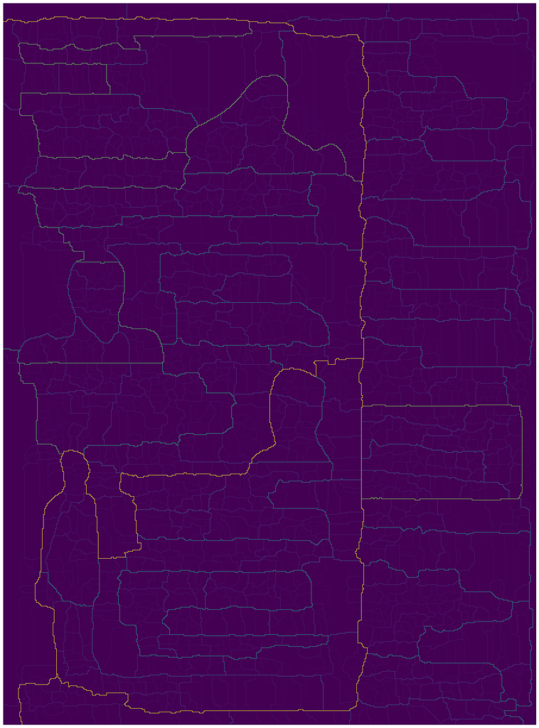

```
(<Figure size 1342.5x1819.5 with 1 Axes>,
```

```python
tree_area, altitudes_area = hg.watershed_hierarchy_by_area(graph, edge_weights)
imshow(hg.graph_4_adjacency_2_khalimsky(graph, hg.saliency(tree_area, altitudes_area))**0.5)
```

```python
print(tree_area.num_vertices())
print(tree_area.children(tree_area.root()))
print(altitudes_area[277933])
print(tree_area.children(tree_area.children(tree_area.root())[0]))
print(altitudes_area[277923])
```

```
297548
[297545 297546]
0.0
[297532 297543]
0.0
```

### Watershed hierarchy by volume

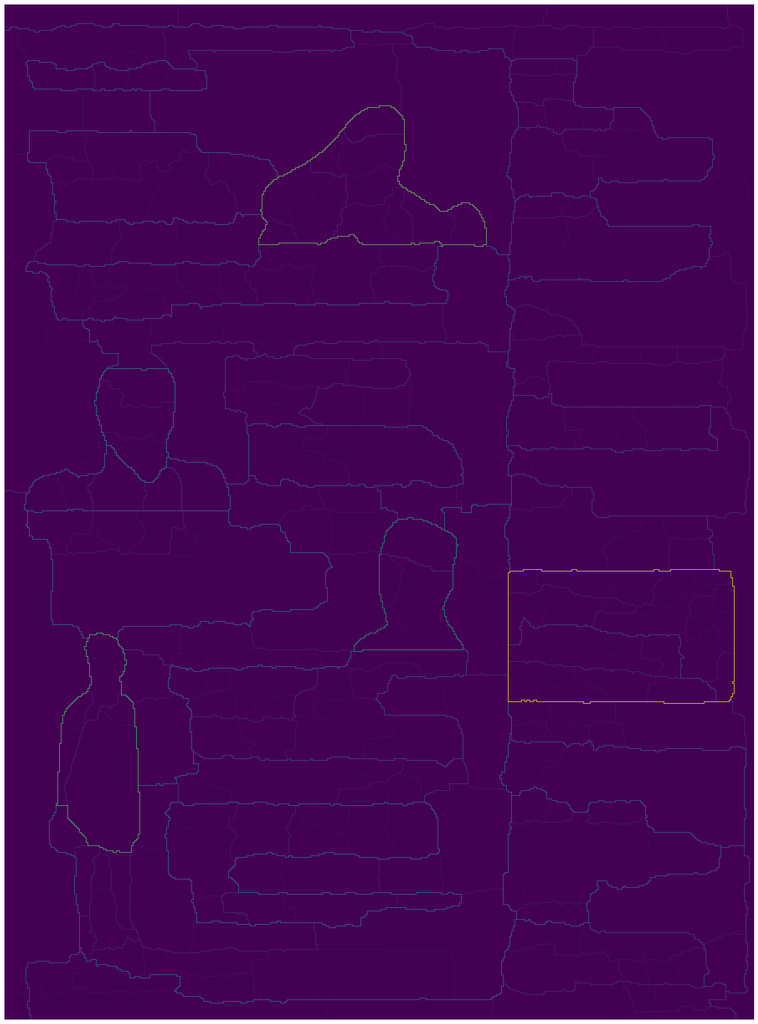

```
(<Figure size 1342.5x1819.5 with 1 Axes>,
```

```python
tree_volume, altitudes_volume = hg.watershed_hierarchy_by_volume(graph, edge_weights)
imshow(hg.graph_4_adjacency_2_khalimsky(graph, hg.saliency(tree_volume, altitudes_volume))**0.5)
```

```python
print(tree_volume.num_vertices())
print(altitudes_volume.max())
```

```
277170
1293.8388671875
```

# Hierarchy creation

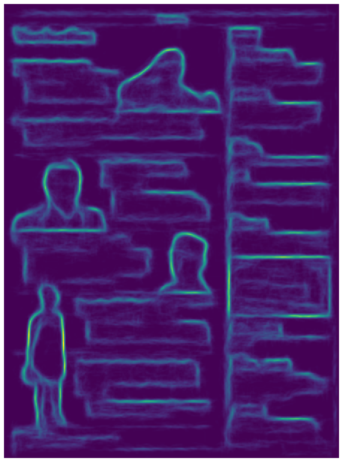

```python
detector = cv2.ximgproc.createStructuredEdgeDetection(get_sed_model_file())
gradient_image = detector.detectEdges(image.astype(np.float32))
imshow(gradient_image);

tree, altitudes = hg.watershed_hierarchy_by_area(graph, edge_weights)
altitudes /= altitudes.max()
```

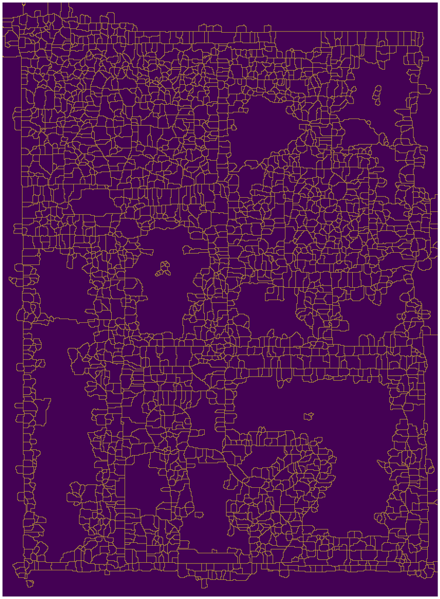

```
(<Figure size 1375.5x1879.5 with 1 Axes>,
```

```python
# then compute the pixel labelisation into watershed basins
labelisation = hg.labelisation_watershed(graph, edge_weights)

# finally, the cut is composed of edges linking two regions with different labels
watershed_cut = hg.weight_graph(graph, labelisation, hg.WeightFunction.L0)

# we can visualize the result in the Khalimsky grid
watershed_cut_khalimsky = hg.graph_4_adjacency_2_khalimsky(graph, watershed_cut)
imshow(watershed_cut_khalimsky)
```

## Horizontal cut explorer

```python
explorer = hg.HorizontalCutExplorer(tree, altitudes)

# this saliency corresponds to edge weights on the base graph
saliency = hg.saliency(tree, altitudes)
# we embedd the saliency values in the Khalimsky grid
saliency_khalimsky = hg.graph_4_adjacency_2_khalimsky(graph, saliency)
```

### a) With only gamma as parameter

```python
def show_saliency(gamma=0.5):
    imshow(1-saliency_khalimsky**gamma, cmap="gray");

interact(show_saliency, gamma= FloatSlider(min=0.01, max=16, continuous_update=False, value=0.5, step=0.05));
```

### b) With gamma and the number of regions as parameters

```python
def show_saliency(num_regions=200, gamma=0.5):
    cut = explorer.horizontal_cut_from_num_regions(num_regions)
    cut_altitude = cut.altitude()
    filtered_saliency = np.where(saliency_khalimsky>=cut_altitude, saliency_khalimsky, cut_altitude)
    filtered_saliency = (filtered_saliency - cut_altitude) / (1 - cut_altitude)
    imshow(1-filtered_saliency**gamma, cmap="gray");

interact(show_saliency,
         num_regions = IntSlider(min=3, max=500, continuous_update=False, value=100, step=1),
         gamma= FloatSlider(min=0.01, max=2, continuous_update=False, value=0.5, step=0.05));
```

## Horizontal cuts

```python
# compute average color and random color for nodes
mean_color = hg.attribute_mean_vertex_weights(tree, image)
random_color = np.random.rand(tree.num_vertices(), 3)
```

```python
def show_cut(num_regions, fill='Mean Color', show_frontiers=True, mode='At least n regions'):
    cut_nodes = explorer.horizontal_cut_from_num_regions(num_regions, at_least=(mode == 'At least n regions'))
    print("Cut with %d regions at altitude %3.2f"%(len(cut_nodes.nodes()), cut_nodes.altitude()))

    im = cut_nodes.reconstruct_leaf_data(tree, mean_color if fill=="Mean Color" else random_color)

    if show_frontiers:
        cut = cut_nodes.graph_cut(tree)
        cut_khal = hg.graph_4_adjacency_2_khalimsky(graph, cut)

        im_khal = np.zeros([size[0] * 2 - 1, size[1] * 2 - 1, 3], dtype=np.float32)
        im_khal[0::2, 0::2, :] = im
        im_khal[0::2, 1::2, :] = im_khal[0::2, 0:-1:2, :]
        im_khal[1::2, 0::2, :] = im_khal[0:-1:2, 0::2, :]
        im_khal[1::2, 1::2, :] = im_khal[0:-1:2, 0:-1:2, :]

        frontiers = cut_khal != 0
        im_khal[frontiers, :] = 0
        im = im_khal

    imshow(im)

interact(show_cut,
         num_regions = IntSlider(min=10, max=10000, continuous_update=False, value=20, step=100),
         mode=["At least n regions", "At most n regions"],
         fill=["Mean Color", "Random Color"],
         show_frontiers=True);
```

# IV. Experimental results

```python
def dataset_analysis(images):
  data = []
  for img in images:
    image = imageio.imread(img)
    image = image.astype(np.float32)/255
    size = image.shape[:2]
    print("Image size: ", size)
    t1 = time.time()
    tree = comp_tree_mtos_2d(image)
    t2 = time.time()
    print("Execution time to construct the MToS : {0:.2f} s".format(t2-t1))
    print("Number of nodes in the MToS: ", tree.num_vertices())
    print("Nbr_nodes ratio/Image_size is : ", tree.num_vertices()/size[0]/size[1])
    # The degree of the tree is the total number of it's children i-e the total number nodes that originate from it.
    print("The degree of the tree is : ", tree.degree(tree.root()))
    print("The height of the tree is : ", hg.attribute_depth(tree).max())
    data.append({"size_img":size,"size_tree":tree.num_vertices(),"ratio":tree.num_vertices()/size[0]/size[1],"degree":tree.degree(tree.root()),"depth":hg.attribute_depth(tree).max(),"time":t2-t1})
  sum_nb_nodes = 0
  sum_ratio = 0
  for item in data:
    sum_nb_nodes += item['size_tree']
    sum_ratio += item['ratio']
  print("\nAverage number of nodes is : ", sum_nb_nodes/len(data))
  print("\nAverage ratio : ", sum_ratio/len(data))
  return data, sum_nb_nodes/len(data), sum_ratio/len(data)
data = dataset_analysis(images)
```

```
Image size:  (617, 461)
Execution time to construct the MToS : 9.51 s
Number of nodes in the MToS:  476080
Nbr_nodes ratio/Image_size is :  1.6737625555043825
The degree of the tree is :  123
The height of the tree is :  706
Image size:  (628, 462)
Execution time to construct the MToS : 7.86 s
Number of nodes in the MToS:  455553
Nbr_nodes ratio/Image_size is :  1.5701360741169659
The degree of the tree is :  3
The height of the tree is :  642
Image size:  (627, 459)
Execution time to construct the MToS : 7.66 s
Number of nodes in the MToS:  456150
Nbr_nodes ratio/Image_size is :  1.5849933806590155
The degree of the tree is :  7
The height of the tree is :  944
Image size:  (607, 448)
Execution time to construct the MToS : 7.19 s
Number of nodes in the MToS:  419119
Nbr_nodes ratio/Image_size is :  1.5412413214874088
The degree of the tree is :  38
The height of the tree is :  881
Image size:  (652, 456)
Execution time to construct the MToS : 9.24 s
Number of nodes in the MToS:  475838
Nbr_nodes ratio/Image_size is :  1.600466849639436
The degree of the tree is :  1
The height of the tree is :  400
Image size:  (624, 458)
Execution time to construct the MToS : 9.73 s
Number of nodes in the MToS:  468951
Nbr_nodes ratio/Image_size is :  1.6408821800470272
The degree of the tree is :  2
The height of the tree is :  1096
Image size:  (628, 462)
Execution time to construct the MToS : 9.60 s
Number of nodes in the MToS:  474135
Nbr_nodes ratio/Image_size is :  1.6341819009016463
```

[output cut: 27 more lines]

```
Execution time to construct the MToS : 9.71 s
Number of nodes in the MToS:  491420
Nbr_nodes ratio/Image_size is :  1.6891464554803937
The degree of the tree is :  1
The height of the tree is :  1111
Image size:  (613, 451)
Execution time to construct the MToS : 9.19 s
Number of nodes in the MToS:  457795
Nbr_nodes ratio/Image_size is :  1.6558997044812507
The degree of the tree is :  1
The height of the tree is :  1580

Average number of nodes is :  506951.76923076925

Average ratio :  1.6336589574786833
```

## 1) The size of the tree

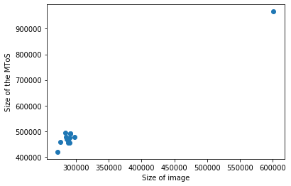

```
Average size of tree is :  506951.76923076925

Average ratio :  1.6336589574786833
```

```python
x_size = []
y_size = []
for item in data[0]:
  x_size.append(item['size_img'][0]*item['size_img'][1])
  y_size.append(item['size_tree'])
plt.scatter(x_size,y_size)
plt.xlabel("Size of image")
plt.ylabel("Size of the MToS")
plt.show()
print("\nAverage size of tree is : ", data[1])
print("\nAverage ratio : ", data[2])
```

## 2) The height of the tree

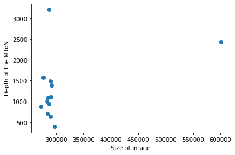

```python
y_depth = []
for item in data[0]:
  y_depth.append(item['depth'])
plt.scatter(x_size,y_depth)
plt.xlabel("Size of image")
plt.ylabel("Depth of the MToS")
plt.show()
```

## 3) The time spent for building the MToS

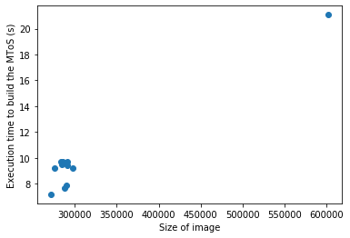

```python
y_time = []
for item in data[0]:
  y_time.append(item['time'])
plt.scatter(x_size,y_time)
plt.xlabel("Size of image")
plt.ylabel("Execution time to build the MToS (s)")
plt.show()
```